# Modelos de Box y Jenkins

Trabajo 2. Análisis de Series de Tiempo

Bladimir Valerio Morales Torrez

Enero 2022

# 1 Introducción

Para este trabajo de análisis de series de tiempo se aplicarán técnicas de modelamiento en series temporales, específicamente los modelos de Box y Jenkins.

La serie de tiempo de estudio para este trabajo es:

- Indice de consumo de agua potable ICAP (enero 1990 a julio 2021).

Se puede encontrar el repositorio de datos y del informe en el siguiente enlace (https://github.com/bladimir-morales/modelos_box_jenkins).

Se puede visualizar el presente informe en formato pdf, en el siguiente enlace:

- https://bladimir-morales.github.io/modelos_box_jenkins/trabajo2.pdf

Se puede visualizar el presente informe en formato html, en el siguiente enlace:

- https://bladimir-morales.github.io/modelos_box_jenkins/trabajo2.html

# 2 Indice de consumo de agua potable ICAP

## 2.1 Datos

El indice mensual de consumo de agua potable de Bolivia ICAP, es un indicador que nos permite conocer *la evolución y comportamiento* del consumo de agua potable de los sectores privado y público a nivel general con año base de 1990, así para este año el indice será igual a 100 y para las siguientes gestiones presentará una variación (incremento o decremento) respecto al año base de acuerdo al consumo de agua potable del mes a tratarse.

## 2.2 Periodo de estudio

La serie de tiempo esta con periodicidad mensual, comprendidos desde enero de 1990 hasta julio de 2021, teniendo en total 379 observaciones.

## 2.3 Fuente de datos

La información del indice mensual de consumo de agua potable de Bolivia se puede encontrar en la página oficial del Instituto Nacional de Estadística (INE)[^1], sección de “Estadísticas Económicas” y subsección “Servicios básicos”. Específicamente se puede descargar los datos en formato establecido por la institución en excel del siguiente enlace: (https://nube.ine.gob.bo/index.php/s/M1H9axannIL7leg/download).

Los metadatos están disponibles en el Catálogo del Archivo Nacional de Datos (ANDA) del INE (http://anda4.ine.gob.bo/ANDA4_2/index.php/catalog/254).

Para fines prácticos se puso la variable en estudio en formato *.txt, el cual puede ser descargada del siguiente enlace (https://raw.githubusercontent.com/bladimir-morales/series_de_tiempo/main/data/agua.txt).

# 3 Gráfico

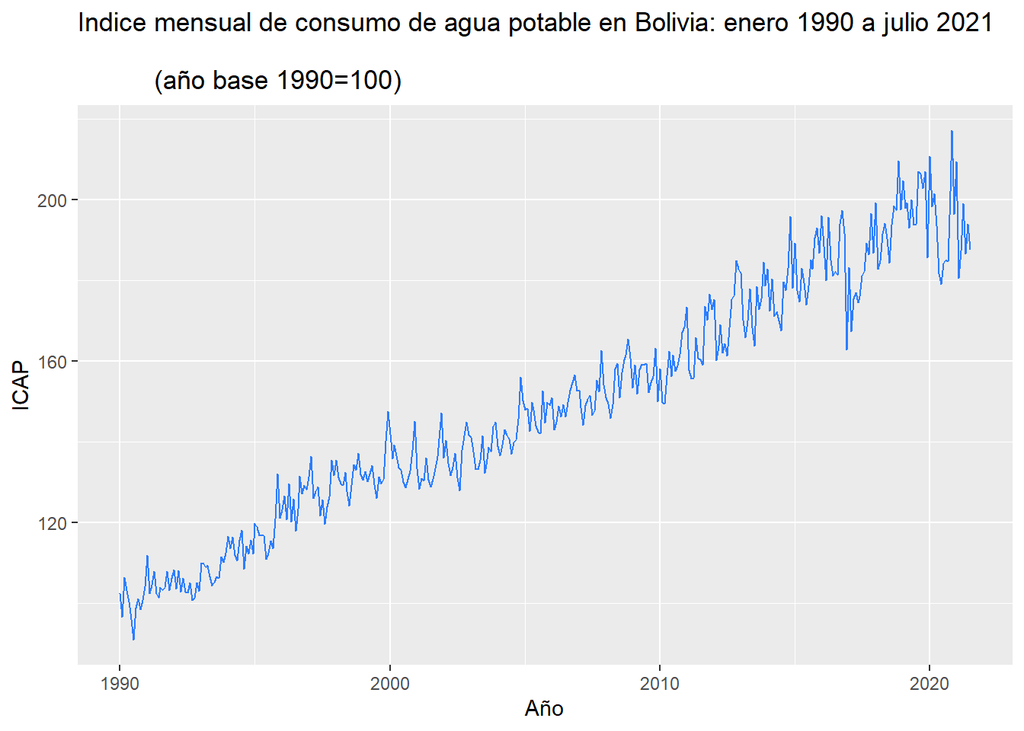

```r
url<-"https://raw.githubusercontent.com/bladimir-morales/modelos_box_jenkins/main/agua.txt?token=AOEHMZISFJOYBMKYVNZE2RLB2VRR4"
agua<-read.table(url,head=T)
serie<-ts(agua$agua,start = c(1990,1),frequency = 12)

autoplot(serie,series = "ICAP")+
  ggtitle("Indice mensual de consumo de agua potable en Bolivia: enero 1990 a julio 2021 \n
          (año base 1990=100)")+
  xlab("Año")+ylab("ICAP")+
  scale_color_manual(values="#2B7DFF")+
  theme(legend.position = "none")
```

En el gráfico visualmente se puede observar que la serie de tiempo en estudio tendría tendencia aditiva y un posible efecto estacional.

# 4 Datos de entrenamiento y test

Para efectos de obtener un modelo óptimo y lo más preciso posible, se dividirá la serie de tiempo en dos conjuntos:

- Conjunto de datos de entrenamiento:

Se tomará en cuenta los datos desde enero de 1990 hasta diciembre de 2019, contando con 360 observaciones.

- Conjunto de datos de test.

Se tomará en cuenta los datos desde enero de 2020 hasta julio de 2021, contando con 19 observaciones.

En el siguiente gráfico se puede observar la serie de entrenamiento y de test.

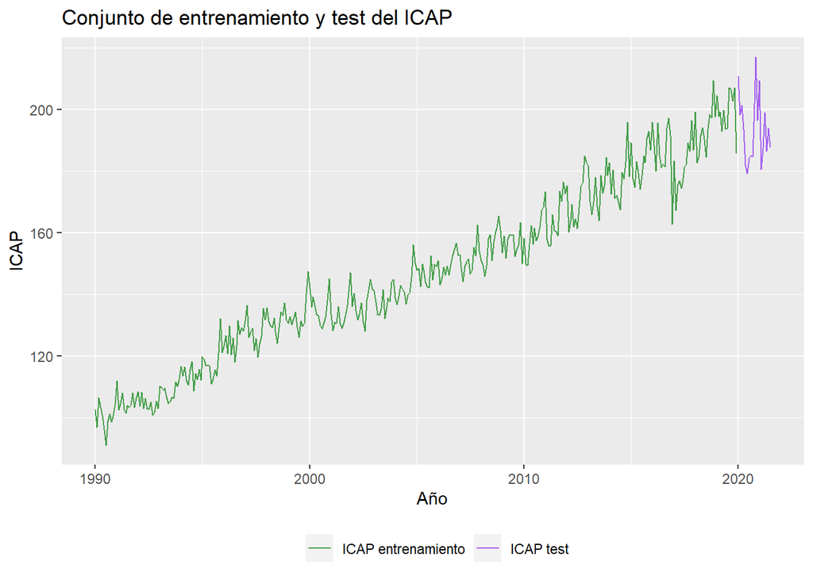

```r
serie_ent<-ts(agua$agua,start = c(1990,1),end = c(2019,12), frequency=12)
serie_test<-ts(agua$agua[361:379],start = c(2020,1), frequency=12)

autoplot(serie_ent,series = "ICAP entrenamiento")+
  autolayer(serie_test,series="ICAP test")+
  ggtitle("Conjunto de entrenamiento y test del ICAP")+
  xlab("Año")+ylab("ICAP")+
  scale_color_manual(values=c("#469F4B","#A462EF"))+
  theme(legend.position = "bottom",legend.title = element_blank() )
```

# 5 Ajuste del Modelo de Box y Jenkins

En esta sección se ajustará un modelo de Box y Jenkins a la serie del ICAP de entrenamiento, para el cual lo primero que se verificara es la estacionariedad (media y varianza) y la estacionalidad de la serie. Posteriormente se realizarán las transformaciones necesarias si es el caso para poder ajustar una serie estacionaria a un modelo de Box y Jenkins.

## 5.1 Estacionariedad

Para poder determinar si la serie del ICAP de entrenamiento es estacionaria en media y varianza se visualizará primero el gráfico de la serie realizando una descomposición de la misma, segundo la función de autocorrelación y tercero se harán pruebas de hipótesis para rechazar o no la hipótesis nula.

### 5.1.1 Análisis gráfico de la serie de entrenamiento y descomposición

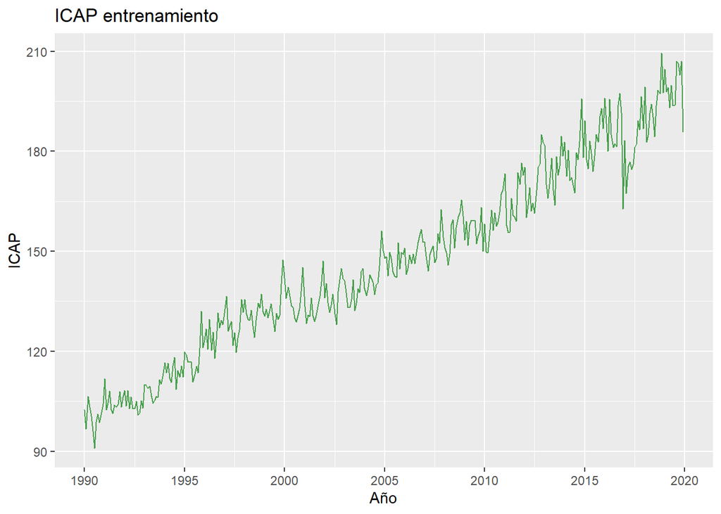

```r
autoplot(serie_ent,series = "ICAP entrenamiento")+
  ggtitle("ICAP entrenamiento")+
  xlab("Año")+ylab("ICAP")+
  scale_color_manual(values=c("#469F4B"))+
  theme(legend.position = "none")
```

Visualmente se puede observar que se tiene una tendencia aditiva y posiblemente estacionalidad multiplicativam, además de presentar varianza no constante en el tiempo.

Para tener mejor precisión de lo mencionado se va a descomponer la serie de tiempo.

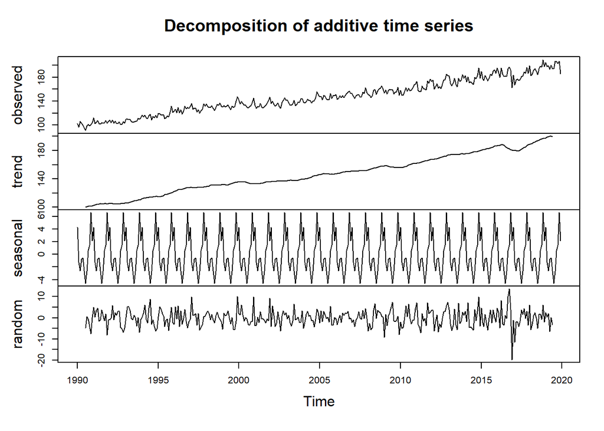

```r
descomposicion<-decompose(serie_ent)
plot(descomposicion)
```

En la descomposición se puede observar que existe una tendencia aditiva y efecto estacional.

Para visualizar de mejor manera la tendencia que es la aplicación de una media móvil de orden $12$ debido a que las observaciones son mensuales se tiene el siguiente gráfico.

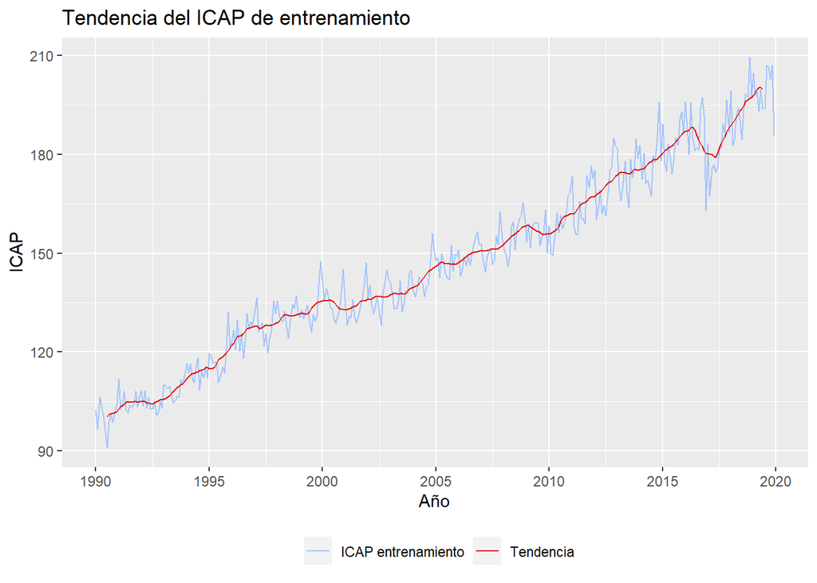

```r
autoplot(serie_ent, series = "ICAP entrenamiento")+
  autolayer(descomposicion$trend,series = "Tendencia")+
  ggtitle("Tendencia del ICAP de entrenamiento")+
  xlab("Año")+ylab("ICAP")+
  scale_color_manual(values=c("#A4C4FC","#E80808"))+
  theme(legend.position = "bottom",legend.title = element_blank())
```

Con la media móvil de orden 12 se puede observar en el gráfico la tendencia aditiva de la serie de tiempo, cabe mencionar que en diciembre del 2016 a aproximadamente junio del 2017 hay una rampa decreciente que puede explicarse por un fenómeno climático de sequía y falta de lluvias en Bolivia, lo cual derivó a un desabastecimiento de agua en ocho de los nueve departamentos del país y en 94 barrios del departamento de La Paz existió un racionamiento de agua, esto se detalla de mejor manera el reportaje de CNN en español en su portal web[^2].

El efecto estacional se estudiara más adelante.

### 5.1.2 Función de autocorrelación FAC

Ahora se vera el gráfico de la función de autocorrelación (FAC) de la serie de entrenamiento del ICAP.

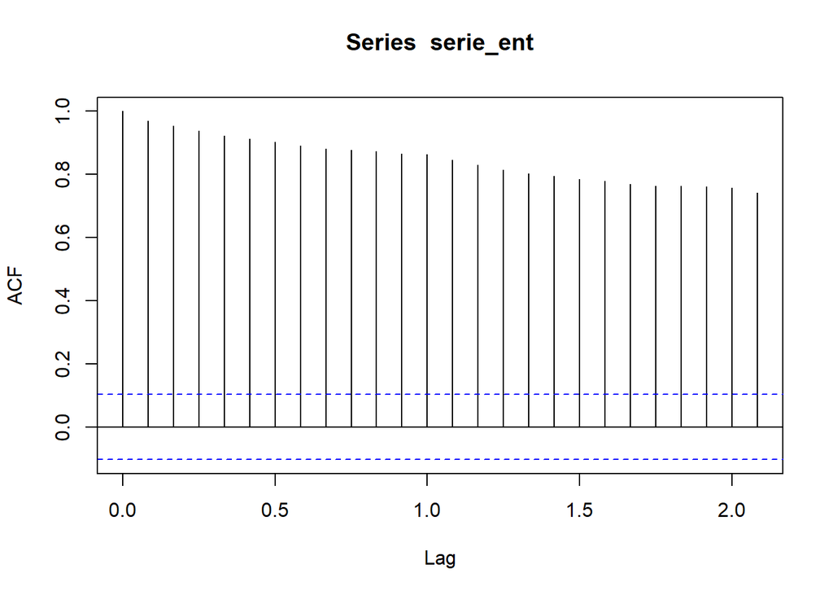

```r
acf(serie_ent)
```

El gráfico de la FAC, no presenta un decaimiento exponencial a $0$, resultando como conclusión la no estacionariedad de la serie.

### 5.1.3 Dócimas de estacionariedad

Para la prueba de estacionariedad se utilizará el test de Dickey Fuller Aumentado donde las hipótesis a contrastar son:

$$H_0: \gamma=0 \;\text{por consiguiente}\; (\phi_1=1)$$
$$H_0: \gamma\neq 0 \;\text{por consiguiente}\; (\phi_1<1)$$
o equivalentemente

$$H_0:\text{ Existe raíz unitaria (no es estacionaria)}$$
$$H_1: \text{ No existe raíz unitaria (es estacionaria)}$$
Se probará el contraste con el siguiente comando:

```r
adf.test(serie_ent)
```

```
##
##  Augmented Dickey-Fuller Test
##
## data:  serie_ent
## Dickey-Fuller = -5.1683, Lag order = 7, p-value = 0.01
## alternative hypothesis: stationary
```

Se puede observar que el $p-valor$ es menor a $0.01$ por el mensaje de alerta que imprime el software, llegando así a la decisión de rechazar la hipótesis nula, lo cual deriva a que la serie seria estacionaria. Lo cual entra en contradicción con el análisis del gráfico, la descomposición y la FAC, hay que tener en cuenta que los rezagos que esta tomando esta prueba por defecto son $7$ y como nuestra serie es mensual realizaremos el test con almenos $12$ rezagos.

```r
adf.test(serie_ent,k=12)
```

```
##
##  Augmented Dickey-Fuller Test
##
## data:  serie_ent
## Dickey-Fuller = -2.4064, Lag order = 12, p-value = 0.4054
## alternative hypothesis: stationary
```

Ahora se puede observar que el $p-valor$ es igual a $0.4054$ llegando a la decisión de no rechazar la hipóstesis nula, lo cual deriva a que la serie no es estacionaria, no entrando en contradicción con los análisis previos.

*Observación:*

Para poder determinar desde qué número de rezagos no se rechaza la hipótesis nula se crea la siguiente iteración de la prueba de Dickey Fuller Aumentado:

```r
for(i in 1:24){
  test<-adf.test(serie_ent,k=i)
  print(paste0("Nro. de rezagos: ",i,", P-valor:",test$p.value))
}
```

```
## [1] "Nro. de rezagos: 1, P-valor:0.01"
## [1] "Nro. de rezagos: 2, P-valor:0.01"
## [1] "Nro. de rezagos: 3, P-valor:0.01"
## [1] "Nro. de rezagos: 4, P-valor:0.01"
## [1] "Nro. de rezagos: 5, P-valor:0.01"
## [1] "Nro. de rezagos: 6, P-valor:0.01"
## [1] "Nro. de rezagos: 7, P-valor:0.01"
## [1] "Nro. de rezagos: 8, P-valor:0.01"
## [1] "Nro. de rezagos: 9, P-valor:0.0694827876230502"
## [1] "Nro. de rezagos: 10, P-valor:0.210253403771682"
## [1] "Nro. de rezagos: 11, P-valor:0.673748480029247"
## [1] "Nro. de rezagos: 12, P-valor:0.405387633132588"
## [1] "Nro. de rezagos: 13, P-valor:0.30119597888132"
## [1] "Nro. de rezagos: 14, P-valor:0.105985971185532"
## [1] "Nro. de rezagos: 15, P-valor:0.059784928367456"
## [1] "Nro. de rezagos: 16, P-valor:0.0891392926003197"
## [1] "Nro. de rezagos: 17, P-valor:0.0774720272028518"
## [1] "Nro. de rezagos: 18, P-valor:0.156593570792597"
## [1] "Nro. de rezagos: 19, P-valor:0.151222714106116"
## [1] "Nro. de rezagos: 20, P-valor:0.175806338988105"
## [1] "Nro. de rezagos: 21, P-valor:0.35232953748354"
## [1] "Nro. de rezagos: 22, P-valor:0.524929774977473"
## [1] "Nro. de rezagos: 23, P-valor:0.782796109884554"
## [1] "Nro. de rezagos: 24, P-valor:0.662107301202331"
```

Como se puede observar desde el rezago $9$ para adelante no se rechaza la hipótesis nula, pensando así que desde ese número de rezagos la serie presenta no estacionariedad.

### 5.1.4 Conclusión de estacionariedad

Posterior a realizar un análisis de la serie del ICAP de Bolivia tanto gráfico, por descomposición, la función de autocorrelación FAC y realizar la prueba de Dickey Fuller Aumentado se concluye que la serie es no estacionaria tanto en media como en varianza, presentando así tendencia positiva y varianza no constante.

## 5.2 Estacionalidad

### 5.2.1 Análisis gráfico

Para determinar de mejor manera el efecto estacional que en primera instancia resulto de la descomposición de la serie de tiempo el cual se refleja en el siguiente gráfico.

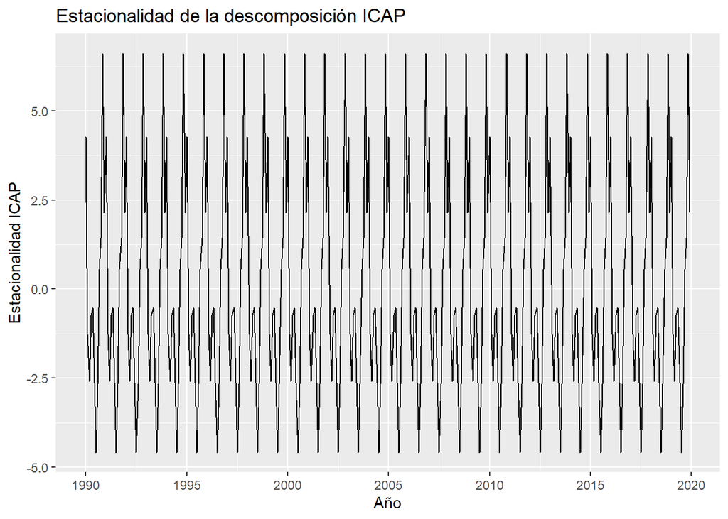

```r
autoplot(descomposicion$seasonal)+
  ggtitle("Estacionalidad de la descomposición ICAP")+
  xlab("Año")+ylab("Estacionalidad ICAP")
```

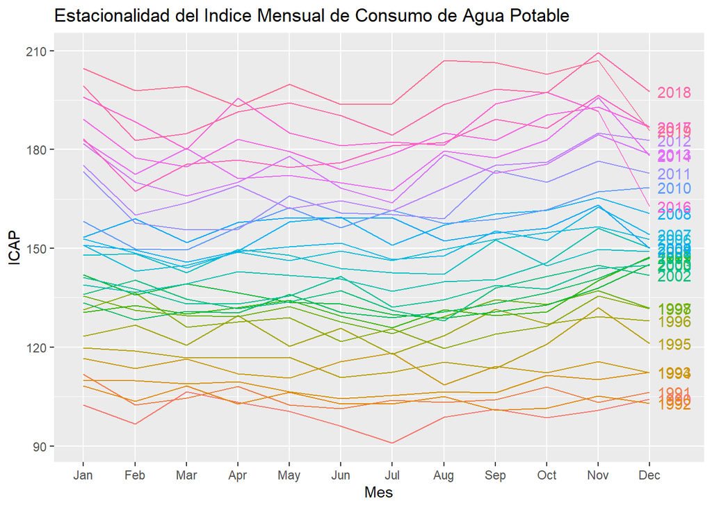

```r
ggseasonplot(serie_ent,main="Estacionalidad del Indice Mensual de Consumo de Agua Potable",
           year.labels = T,xlab="Mes",ylab="ICAP")
```

En este gráfico se puede observar en primera instancia que existe una tendencia aditiva lo cual verifica lo mostrado anteriormente, ya que a medida que pasa cada año el consumo de agua potable va aumentando, por otro lado no se presente de manera clara el efecto estacional, pero en el mes de noviembre se puede ver un leve incremento de la serie en estudio.

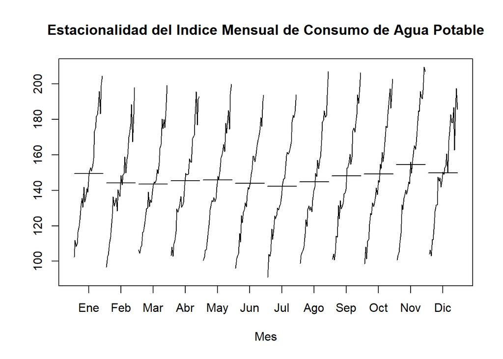

```r
monthplot(serie_ent,ylab="",main="Estacionalidad del Indice Mensual de Consumo de Agua Potable",
          labels = c("Ene","Feb","Mar","Abr","May","Jun","Jul","Ago","Sep","Oct","Nov","Dic"),
          xlab="Mes")
```

En este último gráfico se puede observar que podría existir un efecto estacional ya que en los meses de enero y noviembre asciende de manera muy leve el consumo de agua potable en Bolivia, pero en los demás meses se mantiene casi constantemente.

### 5.2.2 Conclusión estacionalidad

Se puede concluir entonces con un análisis visual que la serie en estudio del indice de consumo de agua potable en Bolivia tiene efecto de tendencia aditiva con estacionalidad.

## 5.3 Transformación de la serie temporal

Como se pudo concluir en los análisis previos de estacionariedad y estacionalidad la serie del ICAP de entrenamiento es no estacionario en media y tampoco en varianza, además de tener efecto estacional, por esos motivos se procederá a realizar transformaciones para poder tener una serie de tiempo estacionaria en media y varianza y sin efecto estacional.

### 5.3.1 Transformación logaritmo

Para poder tener varianza constante se utilizará la transformación logaritmo a la serie del ICAP de entrenamiento.

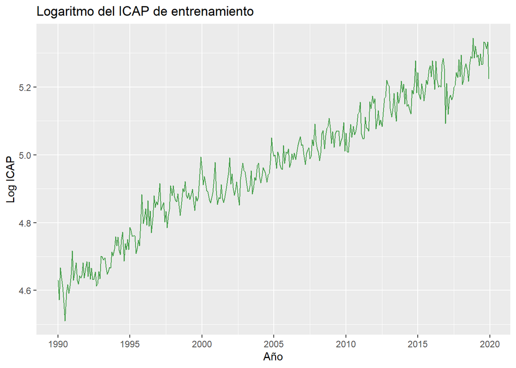

```r
log_serie_ent<-log(serie_ent)

autoplot(log_serie_ent,series="Logaritmo de ICAP entrenamiento")+
  ggtitle("Logaritmo del ICAP de entrenamiento")+
  xlab("Año")+ylab("Log ICAP")+
  scale_color_manual(values=c("#469F4B"))+
  theme(legend.position = "none")
```

Se puede visualizar que la serie ya no cuenta con varianza creciente conforme pasa el tiempo.

### 5.3.2 Diferenciación

Como la serie aplicada a logaritmo aún presenta tendencia se hará una diferencia con rezago $1$.

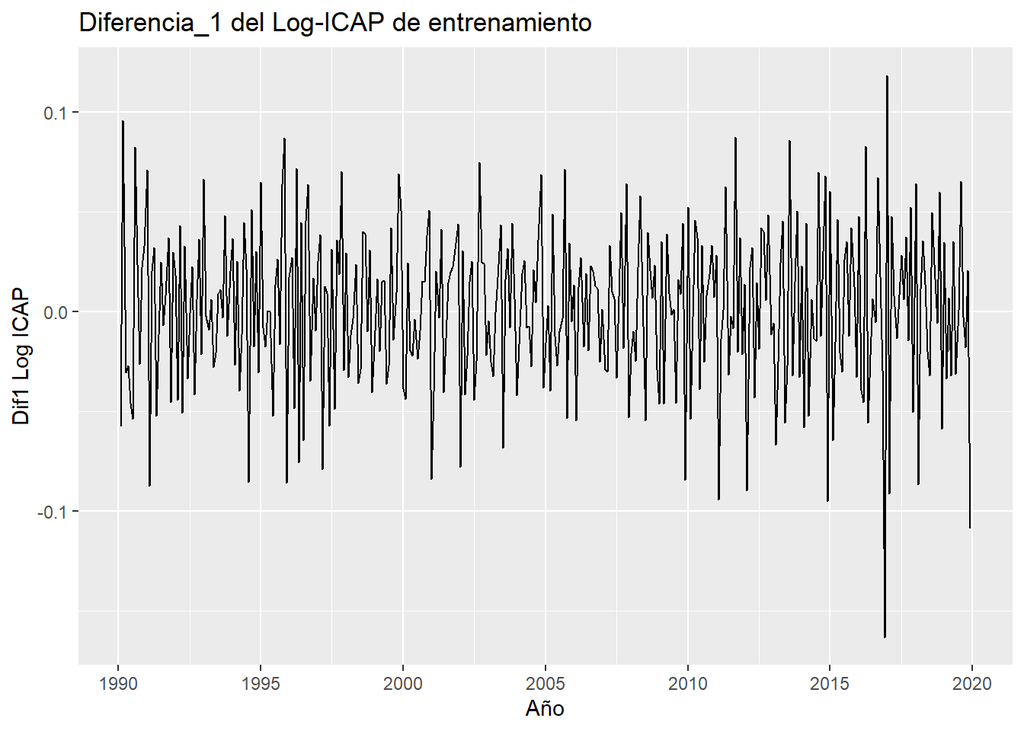

```r
dif_log_serie_ent<-diff(log_serie_ent,1)

autoplot(dif_log_serie_ent)+
  ggtitle("Diferencia_1 del Log-ICAP de entrenamiento")+
  xlab("Año")+ylab("Dif1 Log ICAP")+
  scale_color_manual(values=c("#469F4B"))+
  theme(legend.position = "none")
```

La serie gráficamente presenta media constante y su varianza también excpeto por el periodo entre el 2016 al 2017 que aumenta su variabilidad.

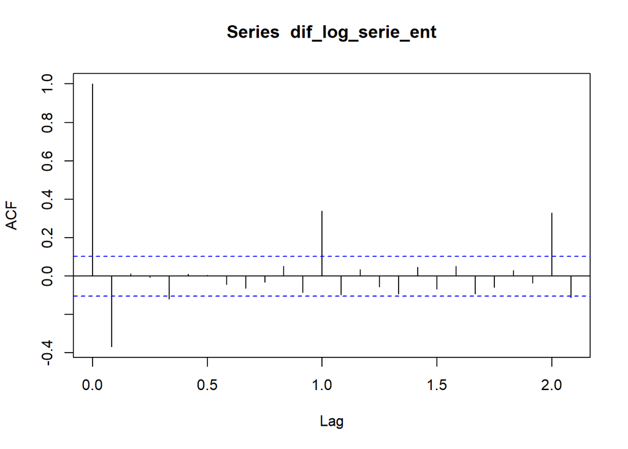

```r
acf(dif_log_serie_ent)
```

Teniendo el gráfico de la función de autocorrelación si existe decaimiento exponencial a $0$, lo cual indica la estacionariedad de la serie de tiempo.

Se hará la prueba de Dickey Fuller Aumentada para verificar estacionariedad.

```r
adf.test(dif_log_serie_ent,k=12)
```

```
##
##  Augmented Dickey-Fuller Test
##
## data:  dif_log_serie_ent
## Dickey-Fuller = -7.6033, Lag order = 12, p-value = 0.01
## alternative hypothesis: stationary
```

Se rechaza la hipótesis nula donde se concluye que la serie es estacionaria, tomando solo una diferencia.

Pero como se analizó anteriormente la serie tenia presumiblemente estacionalidad lo cual se podría quitar con una diferenciación de $12$ rezagos, a la serie aplicada con logaritmo y diferenciada una vez con $1$ rezago.

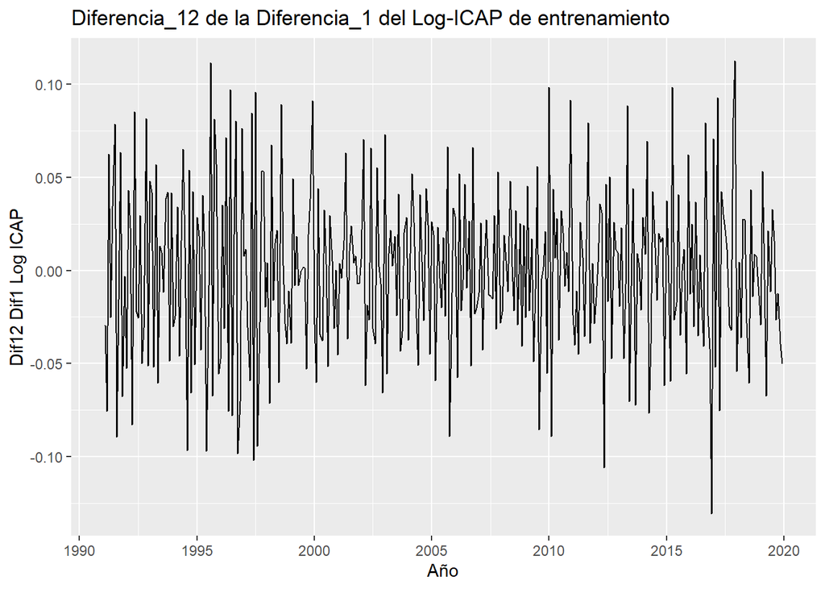

```r
dif12_dif_log_serie_ent<-diff(dif_log_serie_ent,12)

autoplot(dif12_dif_log_serie_ent)+
  ggtitle("Diferencia_12 de la Diferencia_1 del Log-ICAP de entrenamiento")+
  xlab("Año")+ylab("Dif12 Dif1 Log ICAP")+
  scale_color_manual(values=c("#469F4B"))+
  theme(legend.position = "none")
```

La serie no presenta tendencia, teniendo media y varianza constante, y tampoco presenta efecto estacional, donde visualmente estaríamos en frente una serie estacionaria.

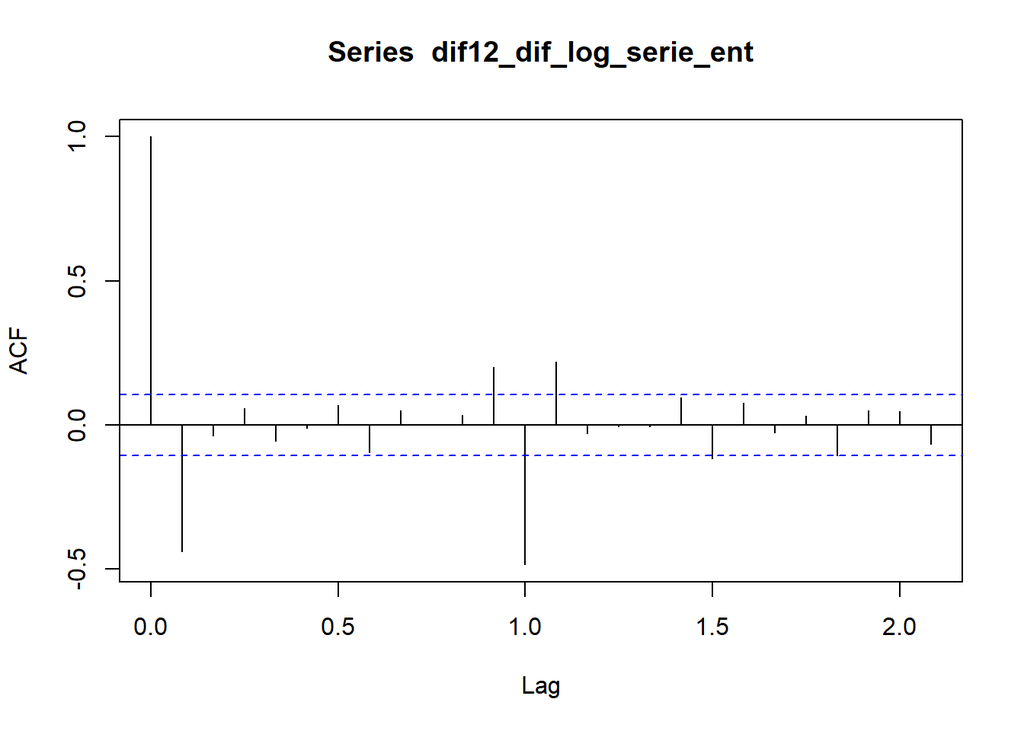

```r
acf(dif12_dif_log_serie_ent)
```

Teniendo el gráfico de la función de autocorrelación existe decaimiento exponencial a $0$, lo cual indica la estacionariedad de la serie de tiempo.

Para comprobar esto probamos el test de Dickey Fuller Aumentado.

```r
adf.test(dif12_dif_log_serie_ent,k=12)
```

```
##
##  Augmented Dickey-Fuller Test
##
## data:  dif12_dif_log_serie_ent
## Dickey-Fuller = -6.7913, Lag order = 12, p-value = 0.01
## alternative hypothesis: stationary
```

Se rechaza la hipótesis nula de raíz unitaria teniendo así una serie estacionaria.

### 5.3.3 Conclusión de las transformaciones

Se puede concluir que se tiene una serie estacionaria aplicando logaritmo y una diferenciación con rezago igual a $1$ a la serie de tiempo del ICAP de Bolivia. No se ve necesario aplicar la diferenciación con rezago igual a $12$ posterior al logaritmo y a la diferenciación con $1$ rezago.

Para consolidar lo que se menciono se procederá a utilizar el comando en R que nos ayuda a ver cuantas diferencias se necesita y así también en la estacionalidad.

```r
paste0("Se necesita diferenciar: ",ndiffs(log_serie_ent)," vez")
```

```
## [1] "Se necesita diferenciar: 1 vez"
```

```r
paste0("Se necesita diferenciar en la parte estacional: ",nsdiffs(log_serie_ent)," veces")
```

```
## [1] "Se necesita diferenciar en la parte estacional: 0 veces"
```

## 5.4 Ajuste del Modelo

Como se pudo determinar en la transformación de la serie se aplico logaritmo para estabilizar varianza y una diferencia de rezago $1$ para que sea estacionaria. No es necesario diferenciar con rezago $12$.

Se grafica las FAC y FACP de la serie transformada.

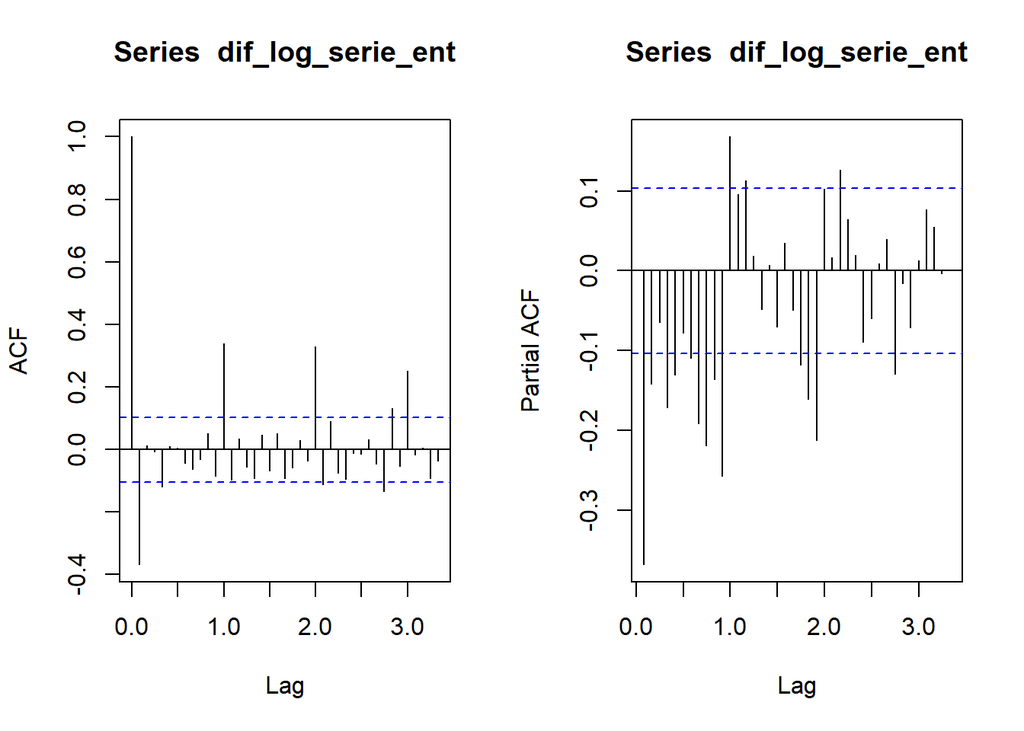

```r
par(mfrow=c(1,2))
acf(dif_log_serie_ent,lag=40)
pacf(dif_log_serie_ent,lag=40)
```

De estas gráficas se puede pensar en estimar los siguientes modelos:

1. $SARIMA(2,1,1)(1,0,1)_{12}$
2. $SARIMA(4,1,1)(0,0,1)_{12}$

### 5.4.1 Modelo 1

$SARIMA(2,1,1)(1,0,1)_{12}$

```r
significancia<-function(modelo,se_modelo){
  prueba_coef<-c()
  for (i in 1:length(modelo)) {
    prueba_coef[i]<-modelo[i]/sqrt(se_modelo[i,i])
    print(paste0(names(modelo[i])," :  ", prueba_coef[i]))
  }
}
```

```r
sarima1<-Arima(log_serie_ent,order = c(2,1,1),seasonal = c(1,0,1))
sarima1
```

```
## Series: log_serie_ent
## ARIMA(2,1,1)(1,0,1)[12]
##
## Coefficients:
##          ar1     ar2      ma1    sar1     sma1
##       0.1886  0.0816  -0.8416  0.9494  -0.7238
## s.e.  0.0890  0.0764   0.0680  0.0229   0.0552
##
## sigma^2 estimated as 0.0008972:  log likelihood=747.76
## AIC=-1483.52   AICc=-1483.28   BIC=-1460.22
```

```r
significancia(sarima1$coef,sarima1$var.coef)
```

```
## [1] "ar1 :  2.11860618467722"
## [1] "ar2 :  1.06775297381627"
## [1] "ma1 :  -12.37978439386"
## [1] "sar1 :  41.4111705610035"
## [1] "sma1 :  -13.1123828669638"
```

Al verificar la significancia de los parámetros estimados que resultan de la división del parámetro estimado entre la desviación estándar del mismo se tiene aproximadamente que todos los mayores a $2$ en valor absoluto son significativos.

Teniendo así que en el ajuste del primer modelo $SARIMA(2,1,1)(1,0,1)_{12}$ el coeficiente autoregresivo de orden $2$ AR(2) es no significativo para el modelo, se estima el mismo quitando ese estimador resultando así un modelo $SARIMA(1,1,1)(1,0,1)_{12}$

```r
sarima1<-Arima(log_serie_ent,order = c(1,1,1),seasonal = c(1,0,1))
sarima1
```

```
## Series: log_serie_ent
## ARIMA(1,1,1)(1,0,1)[12]
##
## Coefficients:
##          ar1      ma1    sar1     sma1
##       0.1282  -0.7780  0.9499  -0.7213
## s.e.  0.0860   0.0624  0.0223   0.0544
##
## sigma^2 estimated as 0.0008969:  log likelihood=747.24
## AIC=-1484.48   AICc=-1484.31   BIC=-1465.06
```

```r
significancia(sarima1$coef,sarima1$var.coef)
```

```
## [1] "ar1 :  1.49046872443294"
## [1] "ma1 :  -12.4698284920309"
## [1] "sar1 :  42.5731003947495"
## [1] "sma1 :  -13.2617744415541"
```

Como se puede observar ahora el coeficiente AR(1) es no significativo para el modelo, por tanto se estima un modelo $SARIMA(0,1,1)(1,0,1)_{12}$

```r
sarima1<-Arima(log_serie_ent,order = c(0,1,1),seasonal = c(1,0,1))
sarima1
```

```
## Series: log_serie_ent
## ARIMA(0,1,1)(1,0,1)[12]
##
## Coefficients:
##           ma1   sar1     sma1
##       -0.6971  0.949  -0.7131
## s.e.   0.0463  0.022   0.0535
##
## sigma^2 estimated as 0.0008996:  log likelihood=746.16
## AIC=-1484.32   AICc=-1484.21   BIC=-1468.79
```

```r
significancia(sarima1$coef,sarima1$var.coef)
```

```
## [1] "ma1 :  -15.0573242513155"
## [1] "sar1 :  43.1679830584975"
## [1] "sma1 :  -13.3163637305963"
```

Así para el modelo $SARIMA(0,1,1)(1,0,1)_{12}$ todos los parámetros estimados son significativos. Para este modelo estimado se tiene un Criterio de información de Akaike AIC

```r
AIC_sarima1<-sarima1$aic
AIC_sarima1
```

```
## [1] -1484.323
```

### 5.4.2 Modelo 2

$SARIMA(4,1,1)(0,0,1)_{12}$

```r
sarima2<-Arima(log_serie_ent,order = c(4,1,1),seasonal = c(0,0,1))
sarima2
```

```
## Series: log_serie_ent
## ARIMA(4,1,1)(0,0,1)[12]
##
## Coefficients:
##          ar1     ar2     ar3      ar4      ma1    sma1
##       0.2641  0.1091  0.0088  -0.1117  -0.8083  0.2739
## s.e.  0.0763  0.0621  0.0591   0.0582   0.0579  0.0447
##
## sigma^2 estimated as 0.001149:  log likelihood=707.86
## AIC=-1401.72   AICc=-1401.4   BIC=-1374.53
```

```r
significancia(sarima2$coef,sarima2$var.coef)
```

```
## [1] "ar1 :  3.46271282429991"
## [1] "ar2 :  1.75565415777994"
## [1] "ar3 :  0.148199798046032"
## [1] "ar4 :  -1.91822355678645"
## [1] "ma1 :  -13.9645264590549"
## [1] "sma1 :  6.12723271581687"
```

Se tiene que en el ajuste del modelo $SARIMA(4,1,1)(0,0,1)_{12}$ el coeficiente autoregresivo de orden $2,3,4$ AR(2), AR(3) y AR(4) es no significativo para el modelo, se estima el mismo quitando ese estimador resultando así un modelo $SARIMA(1,1,1)(0,0,1)_{12}$

```r
sarima2<-Arima(log_serie_ent,order = c(1,1,1),seasonal = c(0,0,1))
sarima2
```

```
## Series: log_serie_ent
## ARIMA(1,1,1)(0,0,1)[12]
##
## Coefficients:
##         ar1      ma1    sma1
##       0.289  -0.8072  0.2823
## s.e.  0.076   0.0468  0.0437
##
## sigma^2 estimated as 0.001164:  log likelihood=704.08
## AIC=-1400.17   AICc=-1400.05   BIC=-1384.63
```

```r
significancia(sarima2$coef,sarima2$var.coef)
```

```
## [1] "ar1 :  3.80309121747723"
## [1] "ma1 :  -17.2641244648079"
## [1] "sma1 :  6.45876424966251"
```

Así para el modelo $SARIMA(1,1,1)(0,0,1)_{12}$ todos los parámetros estimados son significativos.

El Criterio de información de Akaike AIC es:

```r
AIC_sarima2<-sarima2$aic
AIC_sarima2
```

```
## [1] -1400.166
```

### 5.4.3 Modelo 3

Para el tercer modelo se estimará un con un comando en R que genera un proceso automático en el ajuste de los modelos Box y Jenkins.

```r
arima_automatico<-auto.arima(log_serie_ent)
arima_automatico
```

```
## Series: log_serie_ent
## ARIMA(2,1,2)(1,0,0)[12] with drift
##
## Coefficients:
##          ar1     ar2      ma1     ma2    sar1   drift
##       0.6291  0.0582  -1.2687  0.2870  0.4291  0.0019
## s.e.  0.2795  0.1264   0.2804  0.2655  0.0543  0.0002
##
## sigma^2 estimated as 0.001018:  log likelihood=728.64
## AIC=-1443.28   AICc=-1442.96   BIC=-1416.1
```

```r
significancia(arima_automatico$coef,arima_automatico$var.coef)
```

```
## [1] "ar1 :  2.25088242862455"
## [1] "ar2 :  0.46019747200534"
## [1] "ma1 :  -4.52468215774098"
## [1] "ma2 :  1.08093830360389"
## [1] "sar1 :  7.90064003626897"
## [1] "drift :  9.5732496543853"
```

Los parámetros estimados AR(2) y MA(2) no son significativos.

```r
AIC_arima_automatico<-arima_automatico$aic
AIC_arima_automatico
```

```
## [1] -1443.281
```

### 5.4.4 Decisión

Se pudo encontrar tres posibles modelos dos de los cuales tienen todos sus coeficientes significativos, para tomar la decisión de cual modelo elegir se utilizará el Criterio de Información de Akaike AIC.

$SARIMA(0,1,1)(1,0,1)_{12}$

```r
AIC_sarima1
```

```
## [1] -1484.323
```

$SARIMA(1,1,1)(0,0,1)_{12}$

```r
AIC_sarima2
```

```
## [1] -1400.166
```

```r
AIC_arima_automatico
```

```
## [1] -1443.281
```

El que tiene mejor AIC es el modelo $SARIMA(0,1,1)(1,0,1)_{12}$ , por tal motivo tomaremos este para realizar la validación de supuestos.